# Part I - Prosper Loan Data

## Multivariate Exploration

```python
# creating a dataset for the year2012
year_flag = (df_clean['LoanOriginationYear'] == '2012')
df12 = df_clean[year_flag]
df12.head()
```

|  | ListingKey | Term | LoanStatus | BorrowerAPR | BorrowerRate | BorrowerState | Occupation | EmploymentStatus | EmploymentStatusDuration | IsBorrowerHomeowner | IncomeRange | DebtToIncomeRatio | StatedMonthlyIncome | LoanOriginalAmount | MonthlyLoanPayment | ListingCategory | LoanOriginationYear | LoanOriginationQuarter |
| --- | --- | --- | --- | --- | --- | --- | --- | --- | --- | --- | --- | --- | --- | --- | --- | --- | --- | --- |
| 3 | 0EF5356002482715299901A | 36 | Current | 0.12528 | 0.0974 | GA | Skilled Labor | Employed | 113.0 | True | $25,000-49,999 | 0.15 | 2875.0 | 10000 | 321.45 | Motorcycle | 2012 | Q4 |
| 10 | 0F123545674891886D9F106 | 60 | Current | 0.27462 | 0.2489 | MD | Fireman | Employed | 300.0 | False | $75,000-99,999 | 0.12 | 7500.0 | 13500 | 395.37 | Debt Consolidation | 2012 | Q2 |
| 15 | 0F483544120452347F48121 | 36 | Defaulted | 0.35797 | 0.3177 | FL | Other | Other | 121.0 | True | $50,000-74,999 | 0.49 | 5500.0 | 4000 | 173.71 | Household Expenses | 2012 | Q2 |
| 30 | 0F57353904771934596FE9F | 36 | Completed | 0.12782 | 0.0999 | CA | Other | Employed | 44.0 | False | $25,000-49,999 | 0.11 | 3750.0 | 10000 | 322.62 | Wedding loans | 2012 | Q1 |
| 31 | 0F683558129866945165D36 | 36 | Current | 0.35797 | 0.3177 | WI | Other | Other | 44.0 | False | $25,000-49,999 | 0.04 | 2250.0 | 2000 | 86.85 | Home Improvement | 2012 | Q3 |

```python
# creating a dataset for the year2013
year = (df_clean['LoanOriginationYear'] == '2013')
df13 = df_clean[year]
df13.head()
```

|  | ListingKey | Term | LoanStatus | BorrowerAPR | BorrowerRate | BorrowerState | Occupation | EmploymentStatus | EmploymentStatusDuration | IsBorrowerHomeowner | IncomeRange | DebtToIncomeRatio | StatedMonthlyIncome | LoanOriginalAmount | MonthlyLoanPayment | ListingCategory | LoanOriginationYear | LoanOriginationQuarter |
| --- | --- | --- | --- | --- | --- | --- | --- | --- | --- | --- | --- | --- | --- | --- | --- | --- | --- | --- |
| 4 | 0F023589499656230C5E3E2 | 36 | Current | 0.24614 | 0.2085 | MN | Executive | Employed | 44.0 | True | $100,000+ | 0.26 | 9583.333333 | 15000 | 563.97 | Home Improvement | 2013 | Q3 |
| 5 | 0F05359734824199381F61D | 60 | Current | 0.15425 | 0.1314 | NM | Professional | Employed | 82.0 | True | $100,000+ | 0.36 | 8333.333333 | 15000 | 342.37 | Debt Consolidation | 2013 | Q4 |
| 6 | 0F0A3576754255009D63151 | 36 | Current | 0.31032 | 0.2712 | KS | Sales | Employed | 172.0 | False | $25,000-49,999 | 0.27 | 2083.333333 | 3000 | 122.67 | Debt Consolidation | 2013 | Q2 |
| 7 | 0F1035772717087366F9EA7 | 36 | Current | 0.23939 | 0.2019 | CA | Laborer | Employed | 103.0 | False | $25,000-49,999 | 0.24 | 3355.750000 | 10000 | 372.60 | Home Improvement | 2013 | Q2 |
| 8 | 0F043596202561788EA13D5 | 36 | Current | 0.07620 | 0.0629 | IL | Food Service | Employed | 269.0 | True | $25,000-49,999 | 0.25 | 3333.333333 | 10000 | 305.54 | Other | 2013 | Q4 |

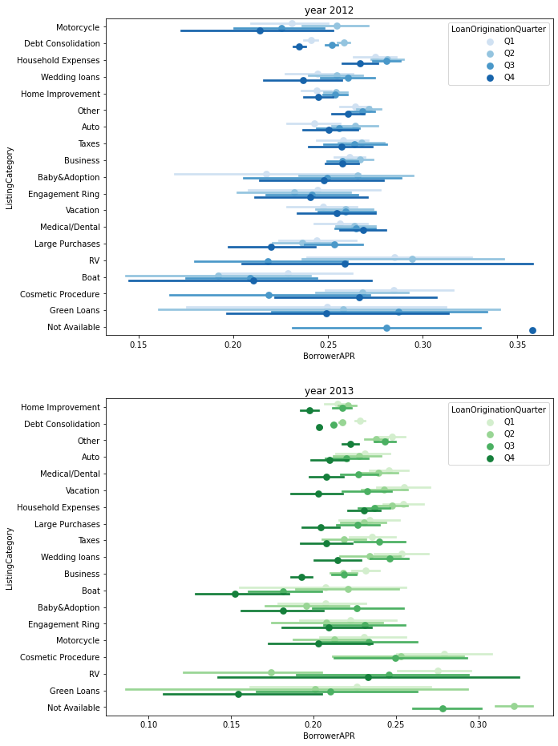

```python
fig, ax = plt.subplots(nrows = 2, figsize = [10,16])

sb.pointplot(data = df12, y = 'ListingCategory', x = 'BorrowerAPR', hue = 'LoanOriginationQuarter',
             palette = 'Blues', linestyles = '', dodge = 0.4, ax = ax[0],)
ax[0].set_title('year 2012')
ax[0].set_ylabel('ListingCategory')

sb.pointplot(data = df13, y = 'ListingCategory', x = 'BorrowerAPR', hue = 'LoanOriginationQuarter',
             palette = 'Greens', linestyles = '', dodge = 0.4, ax = ax[1])
ax[1].set_title('year 2013')
ax[1].set_ylabel('ListingCategory')
plt.show();
```

here i wanted to see the most reasons for people to take loans during the different quarters in 2012 and 2013, and as the scatter plots show that: during 2012 average BorrowerAPR was between 0.20-0.30 but in the 2013 it seems like it narrow down to became between 0.20 and 0.25, as the plots demonstrate during the first quarter of 2013 Cosmetic Procedure has the highest APR average following by RV while in 2012 same two categories were also the highest during the first quarter but for the second quarter of 2012 the RV average increase to became the highest average duing the whole year but Cosmetic Procedure declined.

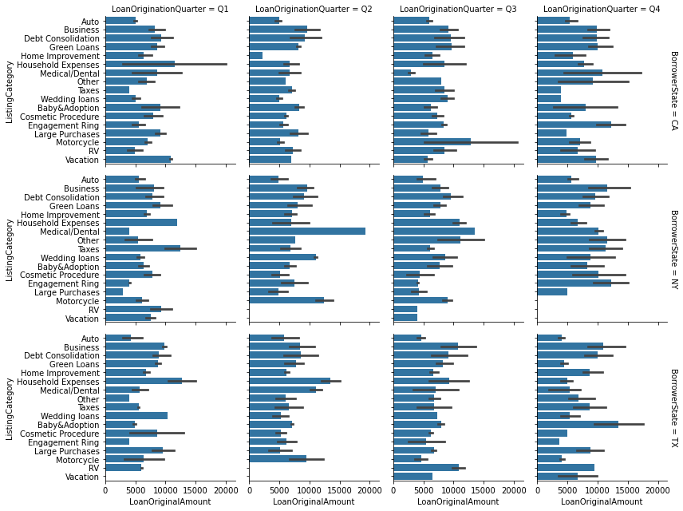

```python
g=sb.FacetGrid(data=df_ym,col='LoanOriginationQuarter',row='BorrowerState', margin_titles =True)
g.map(sb.barplot,'LoanOriginalAmount','ListingCategory')
plt.show()
```

for these barplots we had the average loan amount for each category on for all the quarters during the years for the tio three states, we will start with CA state on the first quarters the houshold ecpenses has the highest average loan Amount followed by vacation but on the second quarters they had a significant drope on the average form 10,000+ till they almost reach 5000 on average, while on the third quarters the medical category got the lowest loan average but on the fourth quarter it has a dramatic increase to became the second highest average. for NY state we continue with the medical category as we can see it has one of the lowst averages but on the second quarters it did increase significantly and for the third and fourth quarters in has some declines to remain about 10,000 and 15,000 average loan amount. in TX baby&Adoption category was about 5000 average on the first quarters then it showed a hike of a couple of thausands to remain steady between 5000 and 10000 then it has upsurged to reach almost 14000 average.

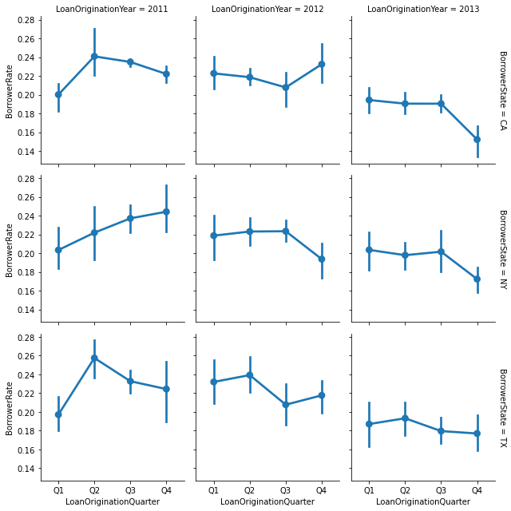

```python
g=sb.FacetGrid(data=df_ym,col='LoanOriginationYear',row='BorrowerState', margin_titles =True)
g.map(sb.pointplot,'LoanOriginationQuarter','BorrowerRate')
plt.show()
```

```python
df_inc.head()
```

|  | BorrowerState | LoanOriginationYear | LoanOriginationQuarter | Occupation | StatedMonthlyIncome | DebtToIncomeRatio |
| --- | --- | --- | --- | --- | --- | --- |
| 0 | CA | 2011 | Q1 | Accountant/CPA | 6755.952381 | 0.152857 |
| 1 | CA | 2011 | Q1 | Administrative Assistant | 3155.861111 | 0.502222 |
| 2 | CA | 2011 | Q1 | Analyst | 8083.333333 | 0.226000 |
| 3 | CA | 2011 | Q1 | Architect | 2500.000000 | NaN |
| 4 | CA | 2011 | Q1 | Attorney | 19166.666667 | 0.080000 |

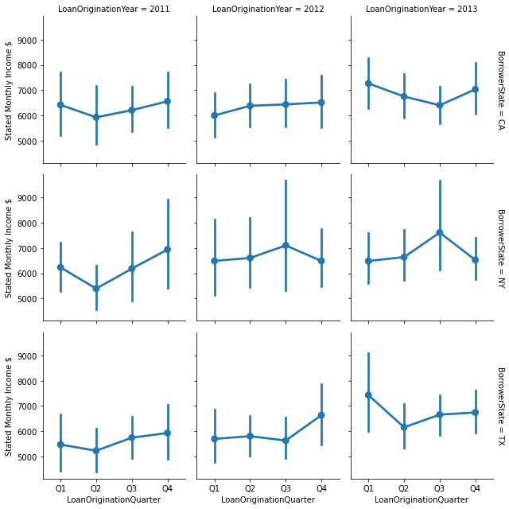

```python
g=sb.FacetGrid(data=df_inc,col='LoanOriginationYear',row='BorrowerState', margin_titles =True)
g.map(sb.pointplot,'LoanOriginationQuarter','StatedMonthlyIncome')
g.set_ylabels('Stated Monthly Income $')
plt.show()
```

Those pointplots illustrate the average stated monthly income for borrowers from three states during the period from 2011 till 2013, Accourding to what is showing on those pointplots we can see that on CA state the average monthly income relarively constant at around 6000 - 7000 except the first quarter of 2013 the average had some increase to get slightly above 7000. and ny state show no big difference the avarege income were about 6000-7000 on most quarters except for the second quarter on 2011 it had grwo smaller to be around5000-6000. for tx state on 2011 and 2012 the average income was about 5000-6000 but on the last quarter of 2012 the average rose to became between 6000-7000 and dto start the next year with an upsure on the average to became between 7000-8000 on the follwing quarterin has decreased to reach slightly above 6000 but then it remaind stable around 6000 and 7000 for the rest of the quarters.

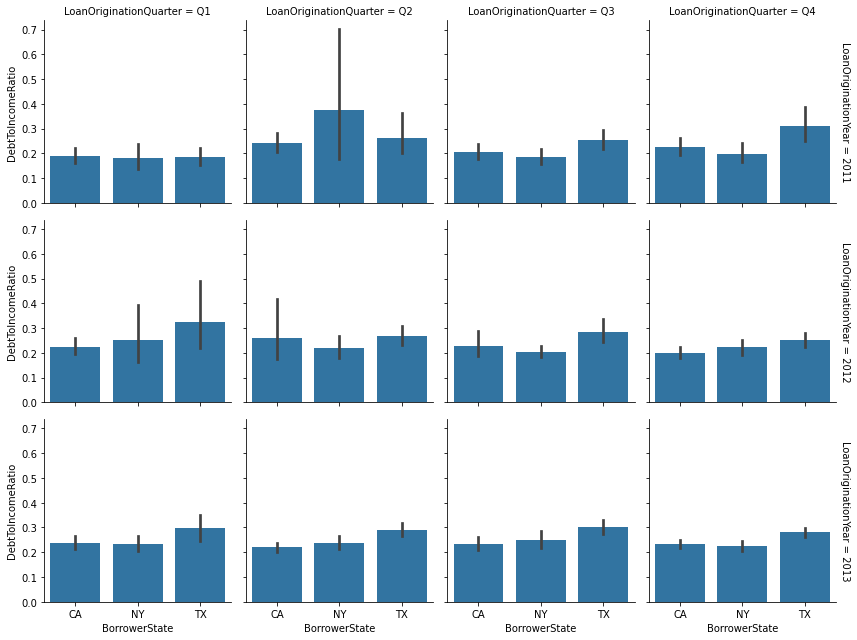

```python
g=sb.FacetGrid(data=df_inc,col='LoanOriginationQuarter',row='LoanOriginationYear', margin_titles =True)
g.map(sb.barplot,'BorrowerState','DebtToIncomeRatio')
```

for the last visulaization i wanted to observe the differences and changes between the ratio of the debt to inccom in the states CA, NY and TX during the quarters for the period from 2011 till 2013, each bin represent a state, as it showing that on the first quarter of 2011 the three states have a very similar debt average to one anothe, but on the second quarter all the states did increase especially NY but on the next quarter the ny average has adramatic fall to reach same average as first quarter and on the fourth quarter all state have a slightly rise on the average. the next year we can notice that CA remaind steady just slightly above 0.2 but the average debt of other two states did grow. on the seecond quarter of 2012 CA state's average did grow but for NY and TX averages they had declined, for the thired quarter VY average debt remaind the same but CA average had some slight drop and TX average did some grow. the last quarter of 2012 CA state continued grwoing smaller unlike NY that got some improvement. on 2013 the average of debt for the three states relatively constant at around 0.2 for CA and 0.3 for TX and slightly above 0.2 for NY the whole year.

### Talk about some of the relationships you observed in this part of the investigation. Were there features that strengthened each other in terms of looking at your feature(s) of interest?

-The barplots show the changes of the average of the loan Amount for each category during the years in the top three states, for CA state on the first quarter household expenses and vacation have the highest average of loan amount, for NY state medical' average on the first quarter was the second lowest category but it got a significant increase on the second quarter.

-The pointplots depicte the interactions between borrowerRate's average and categorical features, on 2011 the three states had increase of the borrowerRate average, but on 2013 the trends were reversed.